# Bellabeat Case Study

Joanna

2024-06-10

# Background

This is a case study for Bellabeat, a company that produces health-focused smart products for women. The goal is to **reveal new opportunities for growth** by analyzing smart device usage data from a set of 30 Fitbit Fitness users over a time period of 31 days. **The analysis will hopefully reveal details about trends in smart device usage** and make it clear how these trends could be used in Bellabeat’s marketing strategy. I will focus on the Bellabeat app, which connects to their line of smart wellness products and provides users with data about their activity, sleep, stress, menstrual cycle and mindfulness habits.

# Ask

The main goal of the analysis is to **find trends that will influence Bellabeat’s marketing strategy** and offer insights into the behaviour of smart device users. The stakeholders are looking for new growth opportunities that could lead to Bellabeat becoming a larger player in the global smart device market.

# Prepare

The data I will use comes from the [FitBit Fitness Tracker Data](https://www.kaggle.com/datasets/arashnic/fitbit). The thirty Fitbit users from this dataset consented to the submission of personal tracker data. It contains information from a 30 day period on users’ total steps, activity levels, calories, heart rate and sleep time.

#### Limitations of the dataset:

- **Number of users** - the data comes from only 30 people, we do not know their age or sex. This information could have improved the analysis, especially considering the fact that Bellabeat’s target audience are women
- **Time frame** - the data only offers information about the usage from 2016-04-12 to 2016-05-12
- **Limited information** - the data doesn’t include information on certain features that Bellabeat’s products offer, for example: stress and menstrual cycle.

# Process

#### Installing and loading necessary packages.

Packages installed: tidyverse, skimr, janitor, here, gridExtra

```r
library(tidyverse)
library(lubridate)
library(dplyr)
library(ggplot2)
library(tidyr)
library(skimr)
library(here)
library(gridExtra)
library(janitor)
library(ggpubr)
```

#### Loading CSV files.

Open source data used from the [FitBit Fitness Tracker Data](https://www.kaggle.com/datasets/arashnic/fitbit): Daily Activity Merged, Sleep Day Merged, Weight Log Info Merged and Heart rate Seconds Merged

#### Data cleaning

- Checking our data and looking for potential problems.

```r
head(daily_activity)
```

```
## # A tibble: 6 × 15
##           Id ActivityDate TotalSteps TotalDistance TrackerDistance
##        <dbl> <chr>             <dbl>         <dbl>           <dbl>
## 1 1503960366 4/12/2016         13162          8.5             8.5
## 2 1503960366 4/13/2016         10735          6.97            6.97
## 3 1503960366 4/14/2016         10460          6.74            6.74
## 4 1503960366 4/15/2016          9762          6.28            6.28
## 5 1503960366 4/16/2016         12669          8.16            8.16
## 6 1503960366 4/17/2016          9705          6.48            6.48
## # ℹ 10 more variables: LoggedActivitiesDistance <dbl>,
## #   VeryActiveDistance <dbl>, ModeratelyActiveDistance <dbl>,
## #   LightActiveDistance <dbl>, SedentaryActiveDistance <dbl>,
## #   VeryActiveMinutes <dbl>, FairlyActiveMinutes <dbl>,
## #   LightlyActiveMinutes <dbl>, SedentaryMinutes <dbl>, Calories <dbl>
```

```r
head(daily_sleep)
```

```
## # A tibble: 6 × 5
##           Id SleepDay        TotalSleepRecords TotalMinutesAsleep TotalTimeInBed
##        <dbl> <chr>                       <dbl>              <dbl>          <dbl>
## 1 1503960366 4/12/2016 12:0…                 1                327            346
## 2 1503960366 4/13/2016 12:0…                 2                384            407
## 3 1503960366 4/15/2016 12:0…                 1                412            442
## 4 1503960366 4/16/2016 12:0…                 2                340            367
## 5 1503960366 4/17/2016 12:0…                 1                700            712
## 6 1503960366 4/19/2016 12:0…                 1                304            320
```

```r
head(weight)
```

```
## # A tibble: 6 × 8
##           Id Date       WeightKg WeightPounds   Fat   BMI IsManualReport   LogId
##        <dbl> <chr>         <dbl>        <dbl> <dbl> <dbl> <lgl>            <dbl>
## 1 1503960366 5/2/2016 …     52.6         116.    22  22.6 TRUE           1.46e12
## 2 1503960366 5/3/2016 …     52.6         116.    NA  22.6 TRUE           1.46e12
## 3 1927972279 4/13/2016…    134.          294.    NA  47.5 FALSE          1.46e12
## 4 2873212765 4/21/2016…     56.7         125.    NA  21.5 TRUE           1.46e12
## 5 2873212765 5/12/2016…     57.3         126.    NA  21.7 TRUE           1.46e12
## 6 4319703577 4/17/2016…     72.4         160.    25  27.5 TRUE           1.46e12
```

```r
head(heart_rate)
```

```
## # A tibble: 6 × 3
##           Id Time                 Value
##        <dbl> <chr>                <dbl>
## 1 2022484408 4/12/2016 7:21:00 AM    97
## 2 2022484408 4/12/2016 7:21:05 AM   102
## 3 2022484408 4/12/2016 7:21:10 AM   105
## 4 2022484408 4/12/2016 7:21:20 AM   103
## 5 2022484408 4/12/2016 7:21:25 AM   101
## 6 2022484408 4/12/2016 7:22:05 AM    95
```

- Changing the date into a date type format:

```r
daily_activity <- daily_activity %>%
  mutate(ActivityDate = as.Date(ActivityDate, format = "%m/%d/%Y"))

daily_sleep <- daily_sleep %>%
  separate(col = SleepDay, c("date", "sleep_time"), sep = " ") %>%
  mutate(date = as.Date(date, format = "%m/%d/%Y"))

heart_rate <- heart_rate %>%
  separate(col = Time, c("date", "sleep_time"), sep = " ") %>%
  mutate(date = as.Date(date, format = "%m/%d/%Y"))
```

- Column name cleaning:

```r
daily_activity <- clean_names(daily_activity)
daily_sleep <- clean_names(daily_sleep)
weight <- clean_names(weight)
heart_rate <- clean_names(heart_rate)
```

- Checking for duplicates and removing them:

```r
sum(duplicated(daily_activity))
```

```
## [1] 0
```

```r
sum(duplicated(daily_sleep))
```

```
## [1] 3
```

```r
sum(duplicated(weight))
```

```
## [1] 0
```

```r
daily_sleep <- daily_sleep %>%
  distinct() %>%
  drop_na()
```

# Analyze

#### Most and least popular features among the users.

First I want to take a look at **the most and least popular features among the users**. In order to do that we need to find out how many distinct users we have for each feature (activity, sleep, heart rate and weight).

```r
activity_users_amount <- n_distinct(daily_activity$id)
sleep_users_amount <- n_distinct(daily_sleep$id)
weight_users_amount <- n_distinct(weight$id)
heartrate_users_amount <- n_distinct(heart_rate$id)
```

We can now group them together and visualize our findings.

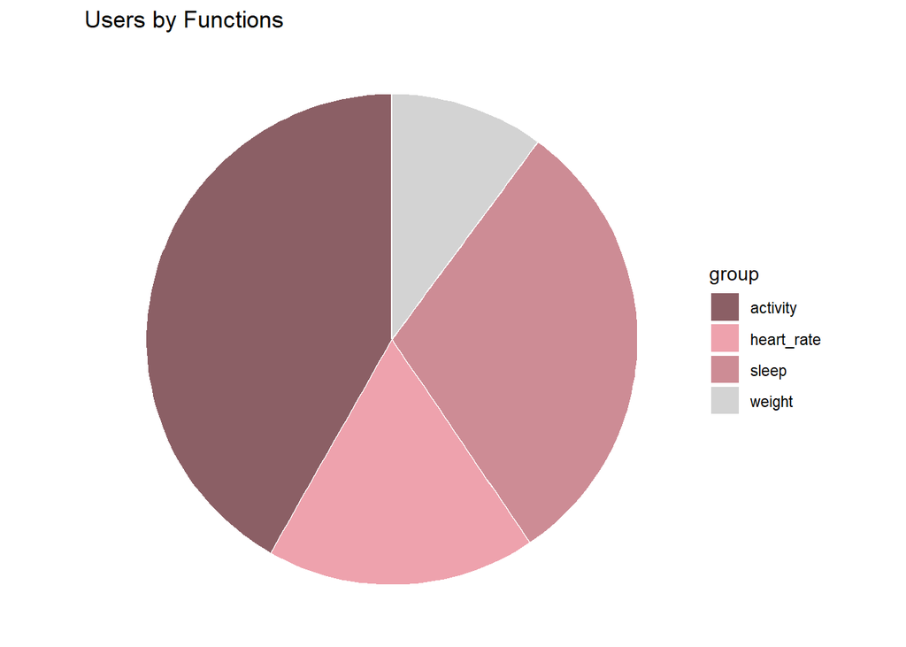

```r
users_by_function <- data.frame(
  group=c("activity", "sleep", "weight", "heart_rate"),
  value=c(activity_users_amount, sleep_users_amount, weight_users_amount, heartrate_users_amount))


ggplot(users_by_function, aes(x="", y=value, fill=group)) +
  geom_bar(stat="identity", width=1, color="white") +
  coord_polar("y", start=0) + theme_void() + scale_fill_manual(values=c("lightpink4", "lightpink2", "lightpink3", "lightgrey")) +
  ggtitle("Users by Functions")
```

We can see that **most users focus on tracking their activity** (33), followed by sleep (24), then heart rate (14) and weight being the last one with only 8 users using this feature.

Since tracking activity is the most popular feature we need to have a closer look at users’ habits.

#### Investigating users’ habits.

To start we’re going to categorize the users based on their average amount on daily steps. To do that we’re going to find the total steps average for the whole data set.

```r
mean(daily_activity$total_steps)
```

```
## [1] 7637.911
```

The average for total steps is around 7640, this will be the number we use for the moderately active users.

```r
daily_average <- daily_activity %>%
  group_by(id) %>%
  summarise(average_daily_steps = mean(total_steps), average_daily_distance = mean(total_distance),
            average_daily_calories = mean(calories))


users_by_activity <- daily_average %>%
  mutate(users_by_activity = case_when(
    average_daily_steps < 3820 ~ "lightly active",
    average_daily_steps <= 7640 ~ "moderately active",
    average_daily_steps > 7640 ~ "very active"
  ))
```

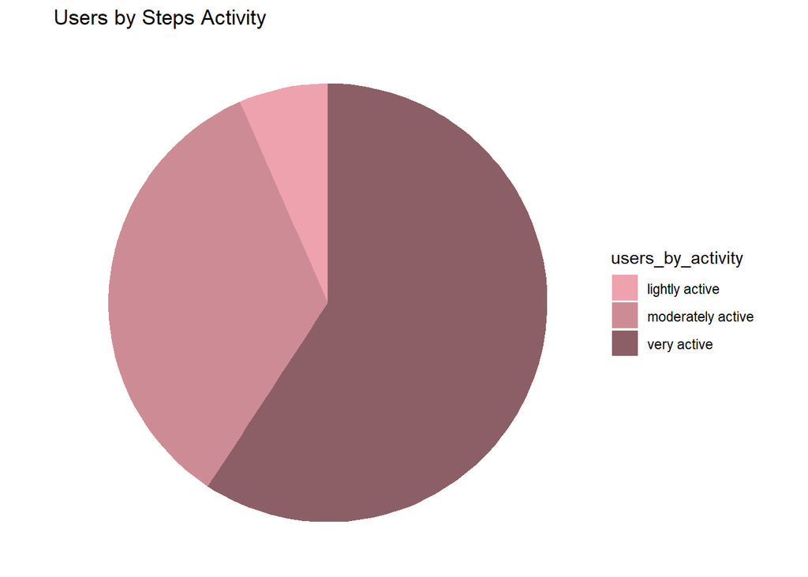

```r
ggplot(users_by_activity, aes(x="", y=users_by_activity, fill=users_by_activity)) +
  geom_bar(stat="identity", width=1) +
  coord_polar("y", start=0) + theme_void() + scale_fill_manual(values=c("lightpink2", "lightpink3", "lightpink4")) +
  ggtitle("Users by Steps Activity")
```

We can see that **most users are very active** (more than 7640 steps a day on average) and only a small amount of users are lightly active (less than 3820 steps a day on average).

We’re going to dive a little bit deeper into users’ habits and check how much time they spend on different levels of activity. We will see if they spend most time on being fairly, lightly or very active, or sedentary.

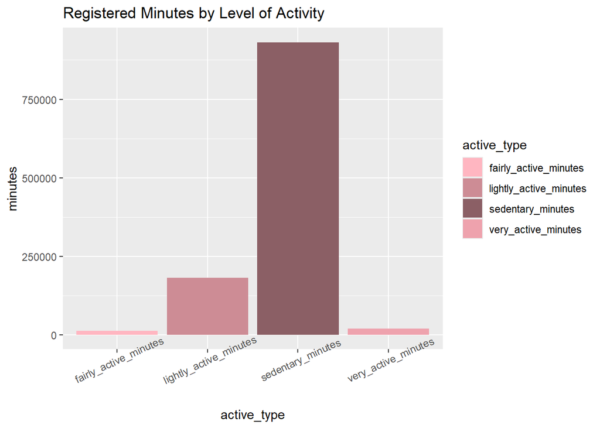

```r
activity_amount <- select(daily_activity, very_active_minutes, fairly_active_minutes, lightly_active_minutes,
                          sedentary_minutes)

daily_activity_long <- activity_amount %>%
  pivot_longer(cols=c("very_active_minutes", "fairly_active_minutes", "lightly_active_minutes", "sedentary_minutes"),
               names_to="active_type",
               values_to="minutes")

ggplot(daily_activity_long, aes(x=active_type, y=minutes, fill=active_type)) +
  geom_bar(stat = "identity") +
  scale_fill_manual(values=c("lightpink","lightpink3", "lightpink4", "lightpink2")) +
  theme(axis.text.x=element_text(angle=25)) +
  labs(title="Registered Minutes by Level of Activity")
```

Sedentary minutes are by far the most prominent, but we can also see that **most of the users’ active minutes are spend on light activities**.

Now let’s check how does the time spent on each level of activity compares to the number of burnt calories.

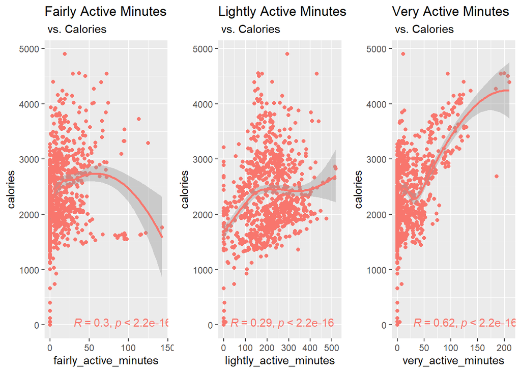

```r
fairly_active_plot <- ggplot(data=daily_activity, mapping=aes(x=fairly_active_minutes,
                                                              y=calories, color="lightpink")) + geom_point() +
  geom_smooth() + labs(title="Fairly Active Minutes", subtitle=" vs. Calories") +
  theme(legend.position = "none") +
  stat_cor(method = "pearson", label.x = 30, label.y = 30)


lightly_active_plot <- ggplot(data=daily_activity, mapping=aes(x=lightly_active_minutes,
                                                             y=calories, color="lightpink2")) + geom_point() +
  geom_smooth() + labs(title="Lightly Active Minutes", subtitle=" vs. Calories") +
  theme(legend.position = "none") +
  stat_cor(method = "pearson", label.x = 30, label.y = 30)


very_active_plot <- ggplot(data=daily_activity, mapping=aes(x=very_active_minutes,
                                                            y=calories, color="lightpink3")) + geom_point() +
  geom_smooth() + labs(title="Very Active Minutes", subtitle=" vs. Calories") +
  theme(legend.position = "none") +
  stat_cor(method = "pearson", label.x = 30, label.y = 30)

grid.arrange(fairly_active_plot, lightly_active_plot, very_active_plot, ncol = 3)
```

We can notice a low correlation between both lightly active minutes and calories, and between fairly active minutes and calories. There is however a **positive correlation between very active minutes and calories**. In a situation, where for many users light activity predominates, it could be useful information if they are interested in increasing the number of burnt calories.

Let’s also check the **correlation between total number of steps and calories**.

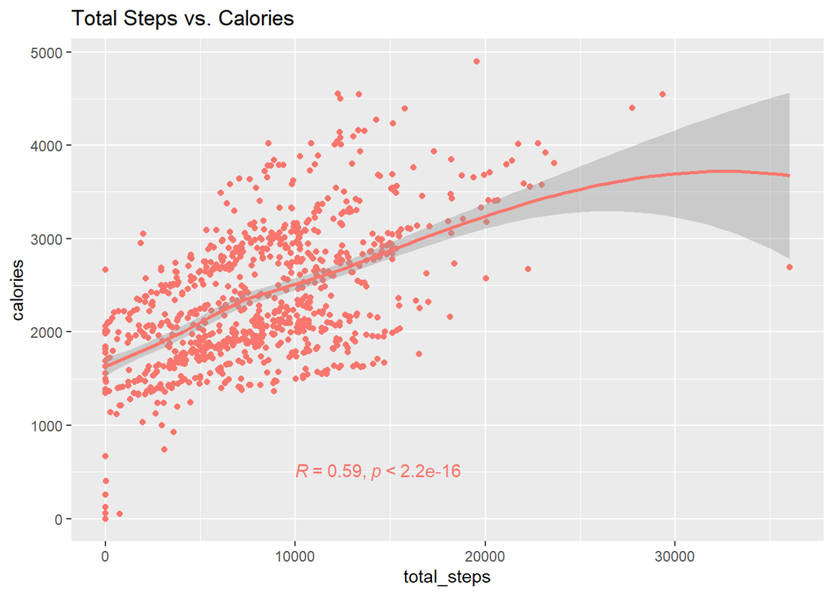

```r
ggplot(data=daily_activity, mapping=aes(x=total_steps, y=calories, color="lightpink4")) + geom_point() +
  geom_smooth() + labs(title="Total Steps vs. Calories") + theme(legend.position = "none") +
  stat_cor(method = "pearson", label.x = 10000, label.y = 500)
```

**We can also observe a positive correlation**, it could be a nice alternative to people who aren’t able to be very active but still care about burning extra calories.

#### Looking at sleep patterns.

To start with we can check what was the minimum, maximum and average amount of minutes the users were asleep for.

```r
max(daily_sleep$total_minutes_asleep)
```

```
## [1] 796
```

```r
min(daily_sleep$total_minutes_asleep)
```

```
## [1] 58
```

```r
mean(daily_sleep$total_minutes_asleep)
```

```
## [1] 419.1732
```

- The maximum amount of total minutes asleep was 796 (~13 hours)
- The minimum amount of total minutes asleep was 58
- The average amount of total minutes asleep was 419 (~7 hours)

**According to [NIH](https://www.nhlbi.nih.gov/health/sleep/how-much-sleep) the recommended amount of sleep for adults is between 7 and 9 hours, which means that on average our users do fit into that recommendation**. However, there are some big outliers, which could be a result of irregular device usage, not wearing the device properly, or even registering a nap. This can cause problems when analyzing the sleep data.

First, we are going to look at how the amount of sleep relates to total steps, very active minutes and lightly active minutes.

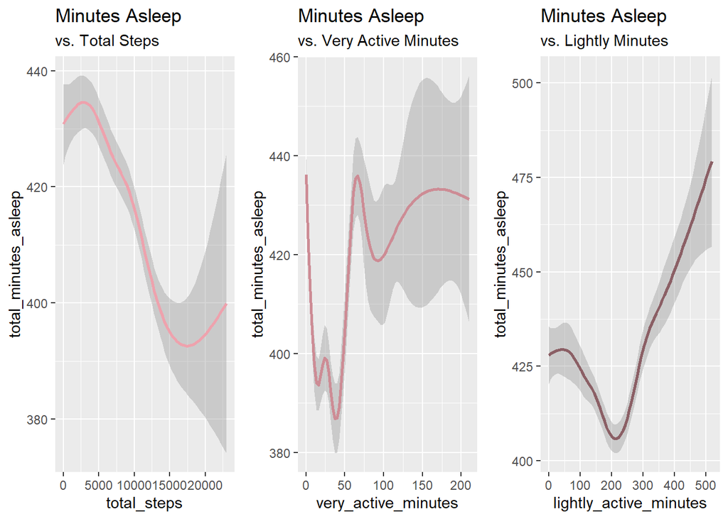

```r
activity_sleep_merged <- merge(daily_activity, daily_sleep, by="id")


plot1 <- ggplot(data=activity_sleep_merged) + geom_smooth(mapping=aes(x=total_steps,
                                                                      y=total_minutes_asleep), color="lightpink2") +
  labs(title="Minutes Asleep", subtitle="vs. Total Steps")

plot2 <- ggplot(data=activity_sleep_merged) + geom_smooth(mapping=aes(x=very_active_minutes,
                                                                      y=total_minutes_asleep), color="lightpink3") +
  labs(title="Minutes Asleep", subtitle="vs. Very Active Minutes")

plot3 <- ggplot(data=activity_sleep_merged) + geom_smooth(mapping=aes(x=lightly_active_minutes,
                                                                      y=total_minutes_asleep), color="lightpink4") +
  labs(title="Minutes Asleep", subtitle="vs. Lightly Minutes")

grid.arrange(plot1, plot2, plot3, ncol = 3)
```

From the first graph we can observe that to reach the minimum recommended amount of sleep, which is 7 hours, or 420 minutes, we shouldn’t exceed 10.000 steps a day. The second graph shows that in most cases a large amount of very active minutes (more than 50) improves our chances of reaching the recommended amount of sleep. According to the last graph getting between 0 and 100 or more than 300 minutes of light activity could also benefit our sleep. There are a lot of different factors that influence the quality of sleep that weren’t considered here, however for people who struggle with getting enough sleep this could provide some helpful guidance.

##### Awake time vs. total time in bed.

Now, we’re going to have a look at the total time the users spend in bed and compare it to the amount of time they spend sleeping and awake.

First we’re going to create a new column that tells us how much time the users stay awake for.

```r
daily_sleep <- daily_sleep %>%
  mutate(awake_time=total_time_in_bed - total_minutes_asleep)
```

Let’s have a look at the minimum, maximum and average values.

```r
time_in_bed <- daily_sleep %>%
  select(awake_time, total_minutes_asleep, total_time_in_bed)

max(time_in_bed$awake_time)
```

```
## [1] 371
```

```r
min(time_in_bed$awake_time)
```

```
## [1] 0
```

```r
mean(time_in_bed$awake_time)
```

```
## [1] 39.30976
```

- The maximum amount of time spent awake in bed is 371 minutes (~6 hours)
- The minimum amount of time spent awake in bed is 0 minutes
- The average amount of time spent awake in bed is 39 minutes

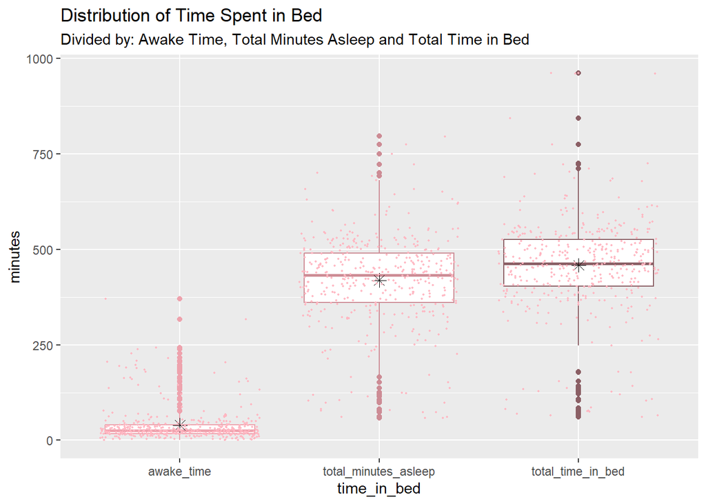

```r
time_in_bed_long <- time_in_bed %>%
  pivot_longer(cols=c("awake_time", "total_minutes_asleep", "total_time_in_bed"),
               names_to="time_in_bed",
               values_to="minutes")


ggplot(time_in_bed_long, mapping=aes(x=time_in_bed, y=minutes, color=time_in_bed)) + geom_boxplot() +
  stat_summary(fun = "mean", geom = "point", shape = 8,
               size = 3, color = "black") +
  geom_jitter(color="lightpink", size=0.4, alpha=0.9) +
  scale_color_manual(values=c("lightpink2", "lightpink3", "lightpink4")) +
  labs(title="Distribution of Time Spent in Bed",
       subtitle="Divided by: Awake Time, Total Minutes Asleep and Total Time in Bed") +
  theme(legend.position = "none")
```

**There is a number of users that spend a lot of time in bed not sleeping**. We don’t have sufficient data to provide reasons for that, however we could use this information to provide Bellabeat app’s users with some help in this matter, for example through guided meditation, stress relief exercises or even alerts about excessive screen time before bed time.

#### Heart Rate.

According to [American Heart Association](https://www.heart.org/en/healthy-living/fitness/fitness-basics/target-heart-rates) for most adults it is normal to have a resting heart rate between 60 and 100 beats per minute.

```r
heart_rate_sorted <- heart_rate %>%
  group_by(id, date) %>%
  summarize(min_heart_rate=min(value), max_heart_rate=max(value), average_heart_rate=mean(value)) %>%
  arrange(max_heart_rate)

head(heart_rate_sorted)
```

```
## # A tibble: 6 × 5
## # Groups:   id [3]
##           id date       min_heart_rate max_heart_rate average_heart_rate
##        <dbl> <date>              <dbl>          <dbl>              <dbl>
## 1 2026352035 2016-04-17             63             80               68.7
## 2 5553957443 2016-04-17             49             84               59.4
## 3 5553957443 2016-04-20             48             84               60.0
## 4 2347167796 2016-04-29             54             85               62.9
## 5 5553957443 2016-04-30             49             89               65.8
## 6 5553957443 2016-04-18             53             91               65.4
```

```r
min(heart_rate_sorted$average_heart_rate)
```

```
## [1] 59.37717
```

```r
max(heart_rate_sorted$average_heart_rate)
```

```
## [1] 109.7896
```

If we look at the average heart rate data of our users, we can see that they almost fit that category. However, our data is limited as we don’t have information about their age and there are no activities assigned to the heart rate. We don’t know if it’s their resting heart rate, or if it’s from being very active. We can see that some users have very low maximum heart rate, which could mean they aren’t doing enough exercise throughout the day. This could be **an opportunity for an app feature that encourages them to move more**.

# Share and Act

#### Recommendations

- **Main Feature Focus**
  1. Tracking activity is the most used feature. Bellabeat’s app could focus on making it even more attractive for users. My suggestion is to **create challenges that encourage users to walk more**, for example by offering rewards, discounts on their products, or simply by **implementing a leaderboard that users could use with their friends and take part in a little bit of healthy competition**.
  2. Majority of users are very active in terms of the amount of steps, Bellabeat’s app could take inspiration from this and **create a community for women who like to walk a lot**. This could be done through organizing events, hikes or city walks or **connecting the women who use their app** and allowing them to build their local walk-loving community.
  3. The amount of sedentary minutes among the users is quite high. **The app could help to improve this by sending notifications reminding them about moving.**
- **Increasing the interest in other features**
  4. To encourage more users to track their sleep patterns, **the app could offer educational materials about the importance of sleep** and how it affects their daily life
  5. To encourage more users to track their weight the app could add information about the amount of burnt calories. The users burn the most calories when they are very active. The app could **introduce a survey that asks the users about their goals** and then customize their experience based on that. In a situation when they’re goal is to lose weight and burn more calories, it could provide them with a counter showing how many very active minutes they should aim for each day and notify them when they reach their goal. There is also a positive correlation between calories and total steps, which could provide a good alternative for users who can’t or simply don’t want to be very active. If they are looking **to burn extra calories they app could increase their daily step goal**.
  6. Bellabeat’s app provides users with data about mindfulness habits. This could be further expanded to **help them with their sleep**. Some users spend too much time in bed awake, the app could **provide guided meditation, stress relief exercises or even alerts about excessive screen time** before bed time to help them minimize this time.
  7. Lastly, the heart rate data showed us that some users don’t increase their heart rate throughout the day almost at all. Bellabeat’s app could **provide information about different heart rate zones** and what is a healthy range for their resting heart rate, but also what heart rate should they maintain while exercising (and for how long) to improve their heart health.

#### Conclusion

Bellabeat aims to inspire and empower women around the world by educating them about their own health and habits. With that in mind and with the conclusions we were able to reach with our analysis the main focus from my recommendations should be on **building a supportive community for women**. There’s nothing more empowering than being surrounded by women who support each other. Expanding all of the features further should come next with more educational material about each measurement.

The data set used for this analysis was quite limited. Collecting data specifically from Bellabeat’s target audience would improve our findings and could provide us with even more specific recommendations.